# Eksplorasi Data Adjusted Closing Price IHSG

Kelompok 14

## Anggota Kelompok

- G14190007 Dhiffa Fatihah Umami
- G14190026 Nenden Maulidia
- G14190043 Tony Alfan
- G14190047 Alvin Christian
- G14190071 Muhammad Hadyan Rizki

## IHSG

Indeks Harga Saham Gabungan (IHSG) merupakan catatan-catatan atas perubahan maupun pergerakan harga saham sejak mulai pertama kali beredar sampai pada suatu saat tertentu. Ada beberapa faktor yang mempengaruhi IHSG, salah satunya adalah faktor makroekonomi seperti tingkat inflasi, nilai tukar rupiah, tingkat suku bunga dan lain-lain (Krisna dan Wirawati 2013).

Indeks Harga Saham Gabungan (IHSG) merupakan suatu nilai untuk mengukur kinerja seluruh saham. IHSG mencerminkan perkembangan pasar secara keseluruhan. Jika IHSG mengalami kenaikan dari hari kemarin maka beberapa saham yang berada pada bursa efek mengalami kenaikan. Oleh karena itu, peramalan harga akan sangat bermanfaat untuk para investor sehingga mereka dapat mengetahui prospek investasi saham di masa yang akan datang (Afittia 2018).

Dataset yang akan digunakan merupakan dataset IHSG dari tanggal 1 Januari 1991 hingga 31 Desember 2020 dengan jumlah 10.958 amatan data. Perekonomian Indonesia selama periode tahun 1990 sampai dengan tahun 2008 banyak mengalami perkembangan yang bersifat positif sampai sebelum tahun 1997 (Santoso Y). Kami tertarik untuk melihat bagaimana performa IHSG setelah melewati beberapa krisis ekonomi seperti krisis moneter 1998, krisis ekonomi global 2008, dan pandemi COVID-19 pada 2020. Karena terdapat banyak missing value, maka perlu dilakukan imputasi. Mengapa bisa ada missing value?

- Bursa Efek Indonesia tidak dibuka pada hari sabtu dan minggu
- Bursa Efek Indonesia tidak dibuka pada tanggal merah

Mengapa perlu dilakukan imputasi? Karena pada hari sabtu & minggu dan pada tanggal merah, masyarakat tetap dapat memiliki perubahan opini terhadap harga saham. Contohnya, perusahaan X terkena kasus pada hari sabtu, maka masyarakat akan cenderung memberikan harga lebih kecil terhadap saham perusahaan X sehingga ketika pasar saham dibuka, harga saham perusahaan X akan langsung menurun. Hal ini juga diperkuat fakta bahwa analisis time series memerlukan seluruh amatan secara lengkap. Metode imputasi yang kami gunakan adalah dengan interpolasi linear.

Harga saham yang akan diamati adalah Adjusted Closing Price (harga closing yang sudah disesuaikan). Harga closing hanya menyatakan harga terakhir ketika pasar saham ditutup. Sedangkan harga closing yang telah disesuaikan mempertimbangkan faktor lain seperti dividen, stock splits, dan penawaran saham baru sehingga bisa menggambarkan nilai saham dengan lebih baik.

## Import data dan Libraries

Importing libraries

```r
library(aTSA)
library(imputeTS)
library(knitr)
library(MASS)
```

Import data dan melihat 10 data pertama.

```r
data <- read.csv("C:/Users/Haci/Desktop/Metode Peramalan Deret Waktu/Project-20220127/IHSG.csv", header=TRUE, sep=";")
data$X <- as.Date(data$X, format="%d/%m/%Y")
datadates <- data.frame(X=seq(as.Date("1991-01-01"), as.Date("2020-12-31"), by="days"))
ihsg <- merge(datadates,data,by="X",all.x=T)

kable(head(ihsg,10), caption="First 10 rows of IHSG daily prices")
```

First 10 rows of IHSG daily prices

| X | JKSE.Open | JKSE.High | JKSE.Low | JKSE.Close | JKSE.Volume | JKSE.Adjusted |
| --- | --- | --- | --- | --- | --- | --- |
| 1991-01-01 | NA | NA | NA | NA | NA | NA |
| 1991-01-02 | NA | NA | NA | NA | NA | NA |
| 1991-01-03 | 408.538 | 408.538 | 408.538 | 408.538 | 0 | 408.538 |
| 1991-01-04 | 408.491 | 408.491 | 408.491 | 408.491 | 0 | 408.491 |
| 1991-01-05 | NA | NA | NA | NA | NA | NA |
| 1991-01-06 | NA | NA | NA | NA | NA | NA |
| 1991-01-07 | 404.817 | 404.817 | 404.817 | 404.817 | 0 | 404.817 |
| 1991-01-08 | 401.647 | 401.647 | 401.647 | 401.647 | 0 | 401.647 |
| 1991-01-09 | 399.133 | 399.133 | 399.133 | 399.133 | 0 | 399.133 |
| 1991-01-10 | 397.383 | 397.383 | 397.383 | 397.383 | 0 | 397.383 |

Dari 10 data pertama, dapat dilihat bahwa terdapat beberapa missing values. Pasar Saham tidak dibuka pada hari sabtu-minggu dan tanggal merah, sehingga dapat dipastikan akan terdapat missingvalue tiap minggunya. Maka akan dilakukan interpolasi linear untuk mengatasi missing value tersebut.

## Imputasi Missing Values

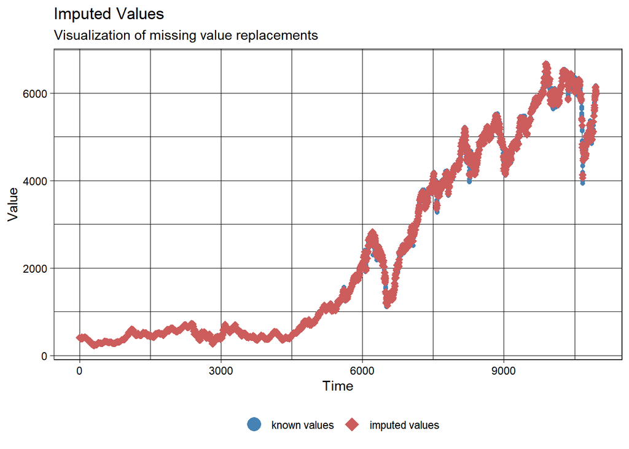

```r
ihsg.imputed <- na_interpolation(ihsg)
ggplot_na_imputations(ihsg$JKSE.Adjusted, ihsg.imputed$JKSE.Adjusted)
```

Dapat kita lihat bahwa imputasi tidak mengubah tren dari harga Adjusted Closing Price. Mari kita coba amati plot time series dari Adjusted Closing Price harian IHSG.